# Supervised Learning - Foundations: ReCell

*Marks: 60*

## Context

Buying and selling used phones and tablets used to be something that happened on a handful of online marketplace sites. But the used and refurbished device market has grown considerably over the past decade, and a new IDC (International Data Corporation) forecast predicts that the used phone market would be worth \$52.7bn by 2023 with a compound annual growth rate (CAGR) of 13.6% from 2018 to 2023. This growth can be attributed to an uptick in demand for used phones and tablets that offer considerable savings compared with new models.

Refurbished and used devices continue to provide cost-effective alternatives to both consumers and businesses that are looking to save money when purchasing one. There are plenty of other benefits associated with the used device market. Used and refurbished devices can be sold with warranties and can also be insured with proof of purchase. Third-party vendors/platforms, such as Verizon, Amazon, etc., provide attractive offers to customers for refurbished devices. Maximizing the longevity of devices through second-hand trade also reduces their environmental impact and helps in recycling and reducing waste. The impact of the COVID-19 outbreak may further boost this segment as consumers cut back on discretionary spending and buy phones and tablets only for immediate needs.

## Objective

The rising potential of this comparatively under-the-radar market fuels the need for an ML-based solution to develop a dynamic pricing strategy for used and refurbished devices. ReCell, a startup aiming to tap the potential in this market, has hired you as a data scientist. They want you to analyze the data provided and build a linear regression model to predict the price of a used phone/tablet and identify factors that significantly influence it.

## Data Description

The data contains the different attributes of used/refurbished phones and tablets. The detailed data dictionary is given below.

**Data Dictionary**

- brand_name: Name of manufacturing brand
- os: OS on which the device runs
- screen_size: Size of the screen in cm
- 4g: Whether 4G is available or not
- 5g: Whether 5G is available or not
- main_camera_mp: Resolution of the rear camera in megapixels
- selfie_camera_mp: Resolution of the front camera in megapixels
- int_memory: Amount of internal memory (ROM) in GB
- ram: Amount of RAM in GB
- battery: Energy capacity of the device battery in mAh
- weight: Weight of the device in grams
- release_year: Year when the device model was released
- days_used: Number of days the used/refurbished device has been used
- new_price: Price of a new device of the same model in euros
- used_price: Price of the used/refurbished device in euros

## Importing necessary libraries and data

```python
# for reading and manipulating data
import numpy as np
import pandas as pd

# for visualizing data
import matplotlib.pyplot as plt
import seaborn as sns

# split the data into train and test
from sklearn.model_selection import train_test_split

# to build linear regression_model
import statsmodels.api as sm

# to check model performance
from sklearn.metrics import mean_absolute_error, mean_squared_error, r2_score
```

## Data Overview

- Observations
- Sanity checks

```python
# reading in data as a dataframe
df = pd.read_csv('used_device_data.csv')
print(df)
```

```
     brand_name       os  screen_size   4g   5g  main_camera_mp  \
0         Honor  Android        14.50  yes   no            13.0
1         Honor  Android        17.30  yes  yes            13.0
2         Honor  Android        16.69  yes  yes            13.0
3         Honor  Android        25.50  yes  yes            13.0
4         Honor  Android        15.32  yes   no            13.0
...         ...      ...          ...  ...  ...             ...
3449       Asus  Android        15.34  yes   no             NaN
3450       Asus  Android        15.24  yes   no            13.0
3451    Alcatel  Android        15.80  yes   no            13.0
3452    Alcatel  Android        15.80  yes   no            13.0
3453    Alcatel  Android        12.83  yes   no            13.0

      selfie_camera_mp  int_memory  ram  battery  weight  release_year  \
0                  5.0        64.0  3.0   3020.0   146.0          2020
```

[output cut: 25 more lines]

```python
# Data Overview
# Viewing first 5 rows
print(df.head())
```

```
  brand_name       os  screen_size   4g   5g  main_camera_mp  \
0      Honor  Android        14.50  yes   no            13.0
1      Honor  Android        17.30  yes  yes            13.0
2      Honor  Android        16.69  yes  yes            13.0
3      Honor  Android        25.50  yes  yes            13.0
4      Honor  Android        15.32  yes   no            13.0

   selfie_camera_mp  int_memory  ram  battery  weight  release_year  \
0               5.0        64.0  3.0   3020.0   146.0          2020
1              16.0       128.0  8.0   4300.0   213.0          2020
2               8.0       128.0  8.0   4200.0   213.0          2020
3               8.0        64.0  6.0   7250.0   480.0          2020
4               8.0        64.0  3.0   5000.0   185.0          2020

   days_used  new_price  used_price
0        127     111.62       74.26
1        325     249.39      174.53
2        162     359.47      165.85
3        345     278.93      169.93
4        293     140.87       80.64
```

```python
# Viewing a sample of 10 rows from the data
df.sample(10)
```

|  | brand_name | os | screen_size | 4g | 5g | main_camera_mp | selfie_camera_mp | int_memory | ram | battery | weight | release_year | days_used | new_price | used_price |
| --- | --- | --- | --- | --- | --- | --- | --- | --- | --- | --- | --- | --- | --- | --- | --- |
| 841 | Others | Android | 12.88 | yes | no | 13.00 | 5.0 | 64.0 | 4.00 | 3180.0 | 167.5 | 2017 | 784 | 170.48 | 94.64 |
| 2926 | Xiaomi | Android | 14.83 | yes | no | 13.00 | 8.0 | 64.0 | 4.00 | 3000.0 | 150.0 | 2018 | 446 | 169.30 | 105.80 |
| 1812 | Meizu | Android | 12.83 | yes | no | 16.00 | 5.0 | 16.0 | 4.00 | 3150.0 | 149.0 | 2016 | 718 | 188.00 | 74.19 |
| 2774 | Spice | Android | 10.29 | no | no | 3.15 | 1.3 | 16.0 | 4.00 | 2100.0 | 130.0 | 2013 | 1054 | 69.27 | 34.73 |
| 480 | Alcatel | Android | 15.24 | yes | no | 12.00 | 5.0 | 32.0 | 4.00 | 4000.0 | 175.0 | 2017 | 823 | 259.20 | 103.59 |
| 101 | Meizu | Android | 15.29 | yes | no | NaN | 16.0 | 64.0 | 6.00 | 4000.0 | 165.0 | 2019 | 517 | 218.91 | 126.76 |
| 1697 | LG | Android | 12.75 | yes | no | 8.00 | 5.0 | 32.0 | 4.00 | 2300.0 | 139.0 | 2015 | 821 | 159.73 | 53.69 |
| 3153 | ZTE | Android | 12.70 | yes | no | 13.00 | 5.0 | 16.0 | 4.00 | 2400.0 | 154.0 | 2015 | 793 | 218.32 | 79.93 |
| 944 | Celkon | Android | 10.16 | no | no | 3.15 | 1.3 | 512.0 | 0.25 | 1400.0 | 115.3 | 2014 | 932 | 59.93 | 20.67 |
| 1556 | Lenovo | Android | 12.83 | yes | no | 5.00 | 0.3 | 16.0 | 4.00 | 2250.0 | 174.0 | 2015 | 765 | 51.27 | 43.84 |

```python
# Shape of dataframe
print(f"The shape of the dataframe is {df.shape}. \nThere are {df.shape[0]} rows and {df.shape[1]} columns")
```

```
The shape of the dataframe is (3454, 15).
There are 3454 rows and 15 columns
```

```python
# Datatypes in dataframe
print(df.dtypes)
```

```
brand_name           object
os                   object
screen_size         float64
4g                   object
5g                   object
main_camera_mp      float64
selfie_camera_mp    float64
int_memory          float64
ram                 float64
battery             float64
weight              float64
release_year          int64
days_used             int64
new_price           float64
used_price          float64
dtype: object
```

```python
# Making a copy of the original dataframe to preserve the original data
df1 = df.copy()

# Converting brand_name, os, 4g, 5g to categorical type from object type
cols = ['brand_name', 'os', '4g', '5g']
df1[cols] = df1[cols].astype('category')

# Verifying conversions applied to columns
print(df1.dtypes)
```

```
brand_name          category
os                  category
screen_size          float64
4g                  category
5g                  category
main_camera_mp       float64
selfie_camera_mp     float64
int_memory           float64
ram                  float64
battery              float64
weight               float64
release_year           int64
days_used              int64
new_price            float64
used_price           float64
dtype: object
```

```python
# Determining if there are any missing values in the dataframe
# Total missing values for each column sorted in descending order
print(df1.isnull().sum().sort_values(ascending=False))
```

```
main_camera_mp      179
weight                7
battery               6
int_memory            4
ram                   4
selfie_camera_mp      2
brand_name            0
os                    0
screen_size           0
4g                    0
5g                    0
release_year          0
days_used             0
new_price             0
used_price            0
dtype: int64
```

```python
# Any missing values?
print("True or False, are there any missing values?", df1.isnull().values.any())
```

```
True or False, are there any missing values? True
```

```python
# Total number of missing values (if any)
print("Total number of missing values (if any) is", df1.isnull().sum().sum())
```

```
Total number of missing values (if any) is 202
```

```python
# Number of unique values in each column sorted in descending order
print(df1.nunique().sort_values(ascending=False))
```

```
used_price          3094
new_price           2988
days_used            924
weight               555
battery              324
screen_size          142
main_camera_mp        41
selfie_camera_mp      37
brand_name            34
int_memory            15
ram                   12
release_year           8
os                     4
4g                     2
5g                     2
dtype: int64
```

```python
# Statistical summary of all data
df1.describe(include = 'all').T
```

|  | count | unique | top | freq | mean | std | min | 25% | 50% | 75% | max |
| --- | --- | --- | --- | --- | --- | --- | --- | --- | --- | --- | --- |
| brand_name | 3454 | 34 | Others | 502 | NaN | NaN | NaN | NaN | NaN | NaN | NaN |
| os | 3454 | 4 | Android | 3214 | NaN | NaN | NaN | NaN | NaN | NaN | NaN |
| screen_size | 3454.0 | NaN | NaN | NaN | 13.713115 | 3.80528 | 5.08 | 12.7 | 12.83 | 15.34 | 30.71 |
| 4g | 3454 | 2 | yes | 2335 | NaN | NaN | NaN | NaN | NaN | NaN | NaN |
| 5g | 3454 | 2 | no | 3302 | NaN | NaN | NaN | NaN | NaN | NaN | NaN |
| main_camera_mp | 3275.0 | NaN | NaN | NaN | 9.460208 | 4.815461 | 0.08 | 5.0 | 8.0 | 13.0 | 48.0 |
| selfie_camera_mp | 3452.0 | NaN | NaN | NaN | 6.554229 | 6.970372 | 0.0 | 2.0 | 5.0 | 8.0 | 32.0 |
| int_memory | 3450.0 | NaN | NaN | NaN | 54.573099 | 84.972371 | 0.01 | 16.0 | 32.0 | 64.0 | 1024.0 |
| ram | 3450.0 | NaN | NaN | NaN | 4.036122 | 1.365105 | 0.02 | 4.0 | 4.0 | 4.0 | 12.0 |
| battery | 3448.0 | NaN | NaN | NaN | 3133.402697 | 1299.682844 | 500.0 | 2100.0 | 3000.0 | 4000.0 | 9720.0 |
| weight | 3447.0 | NaN | NaN | NaN | 182.751871 | 88.413228 | 69.0 | 142.0 | 160.0 | 185.0 | 855.0 |
| release_year | 3454.0 | NaN | NaN | NaN | 2015.965258 | 2.298455 | 2013.0 | 2014.0 | 2015.5 | 2018.0 | 2020.0 |
| days_used | 3454.0 | NaN | NaN | NaN | 674.869716 | 248.580166 | 91.0 | 533.5 | 690.5 | 868.75 | 1094.0 |
| new_price | 3454.0 | NaN | NaN | NaN | 237.038848 | 194.302782 | 18.2 | 120.3425 | 189.785 | 291.115 | 2560.2 |
| used_price | 3454.0 | NaN | NaN | NaN | 92.302936 | 54.701648 | 4.65 | 56.4825 | 81.87 | 116.245 | 749.52 |

### Observations

- The dataset has 3454 rows and 15 columns
- Of the 15 columns, nine are of type float64, two are int64, and the remaining four are object datatypes, which will be converted to categorical to reduce space and be used for building the linear regression model.
  - brand_name, object
  - os, object
  - screen_size, float64
  - 4g, object
  - 5g, object
  - main_camera_mp, float64
  - selfie_camera_mp, float64
  - int_memory, float64
  - ram, float64
  - battery, float64
  - weight, float64
  - release_year, int64
  - days_used, int64
  - new_price, float64
  - used_price, float64
- There are missing values in the dataframe. Of the 15 columns, six columns having missing data. The six columns with missing data, number of rows with missing data, and datatype of columns are listed below.
  - main_camera_mp, 179 missing values, float64
  - selfie_camera_mp, 2 missing values, float64
  - int_memory, 4 missing values, float64
  - ram, 4 missing values, float64
  - battery, 6 missing values, float64
  - weight, 7 missing values, float64
- The target variable (`used_price`) doesn't have any missing values and is type float.
- An initial Exploratory Data Analysis (EDA) with the missing data will be performed to see how the missing data impacts the dataset as well as determine what appropriate techniques need to be used for handling the missing data.
- ~90% (3094/3454) of the used_prices are unique for the used devices.
- ~87% (2988/3454) of the new_prices are unique for the new devices.
- There are 34 device brands in the dataset.
- Android is the most common device OS with 3214 devices running on Android.
- ~68% (2335/3454) of the devices have 4G.
- For screen_size, the min, max, and average values are ~5.1 cm, 30.7 cm, and 13.7 cm
- For main_camera_mp, the min, max, and average values are 0.08 MP, 48 MP, and ~9.5 MP
- For selfie_camera_mp, the min, max, and average values are 0 MP, 32 MP, and ~6.6 MP
- For int_memory, the min, max, and average values are 0.01 GB, 1024 GB, and ~54.6 GB
- For ram, the min, max, and average values are 0.02 GB, 12 GB, and 4 GB
- For battery, the min, max, and average values are 500 mAh, 9720 mAh, and 3133.4 mAh

## Exploratory Data Analysis (EDA) (Before Data Preprocessing)

- EDA is an important part of any project involving data.
- It is important to investigate and understand the data better before building a model with it.
- A few questions have been mentioned below which will help you approach the analysis in the right manner and generate insights from the data.
- A thorough analysis of the data, in addition to the questions mentioned below, should be done.

```python
# function to plot a boxplot and a histogram along the same scale.


def histogram_boxplot(data, feature, figsize=(12, 7), kde=False, bins=None):
    """
    Boxplot and histogram combined

    data: dataframe
    feature: dataframe column
    figsize: size of figure (default (12,7))
    kde: whether to the show density curve (default False)
    bins: number of bins for histogram (default None)
    """
    f2, (ax_box2, ax_hist2) = plt.subplots(
        nrows=2,  # Number of rows of the subplot grid= 2
        sharex=True,  # x-axis will be shared among all subplots
        gridspec_kw={"height_ratios": (0.25, 0.75)},
        figsize=figsize,
    )  # creating the 2 subplots
    sns.boxplot(
        data=data, x=feature, ax=ax_box2, showmeans=True, color="violet"
    )  # boxplot will be created and a star will indicate the mean value of the column
    sns.histplot(
        data=data, x=feature, kde=kde, ax=ax_hist2, bins=bins, palette="winter"
    ) if bins else sns.histplot(
        data=data, x=feature, kde=kde, ax=ax_hist2
    )  # For histogram
    ax_hist2.axvline(
        data[feature].mean(), color="green", linestyle="--"
    )  # Add mean to the histogram
    ax_hist2.axvline(
        data[feature].median(), color="black", linestyle="-"
    )  # Add median to the histogram
```

```python
# function to create labeled barplots


def labeled_barplot(data, feature, perc=False, n=None):
    """
    Barplot with percentage at the top

    data: dataframe
    feature: dataframe column
    perc: whether to display percentages instead of count (default is False)
    n: displays the top n category levels (default is None, i.e., display all levels)
    """

    total = len(data[feature])  # length of the column
    count = data[feature].nunique()
    if n is None:
        plt.figure(figsize=(count + 1, 5))
    else:
        plt.figure(figsize=(n + 1, 5))

    plt.xticks(rotation=90, fontsize=15)
    ax = sns.countplot(
        data=data,
        x=feature,
        palette="Paired",
        order=data[feature].value_counts().index[:n].sort_values(),
    )

    for p in ax.patches:
        if perc == True:
            label = "{:.1f}%".format(
                100 * p.get_height() / total
            )  # percentage of each class of the category
        else:
            label = p.get_height()  # count of each level of the category

        x = p.get_x() + p.get_width() / 2  # width of the plot
        y = p.get_height()  # height of the plot

        ax.annotate(
            label,
            (x, y),
            ha="center",
            va="center",
            size=12,
            xytext=(0, 5),
            textcoords="offset points",
        )  # annotate the percentage

    plt.show()  # show the plot
```

## Univariate Analysis

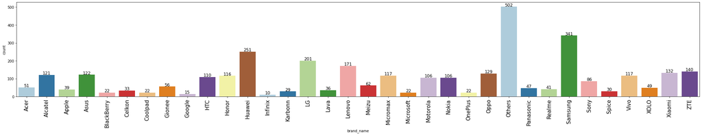

```python
# brand_name
labeled_barplot(df1, 'brand_name')
```

```python
# Since the values for each brand name is hard to see on the barplot, displaying value counts for each brand
df1.brand_name.value_counts().sort_values(ascending=False)
```

```
Others        502
Samsung       341
Huawei        251
LG            201
Lenovo        171
ZTE           140
Xiaomi        132
Oppo          129
Asus          122
Alcatel       121
Vivo          117
Micromax      117
Honor         116
HTC           110
Nokia         106
Motorola      106
Sony           86
Meizu          62
Gionee         56
Acer           51
XOLO           49
Panasonic      47
Realme         41
Apple          39
Lava           36
Celkon         33
Spice          30
Karbonn        29
Microsoft      22
OnePlus        22
Coolpad        22
BlackBerry     22
Google         15
Infinix        10
Name: brand_name, dtype: int64
```

```python
# Displaying brand_names in descending order by percentage in the dataset
df1.brand_name.value_counts(normalize = True).sort_values(ascending=False)*100
```

```
Others        14.533874
Samsung        9.872611
Huawei         7.266937
LG             5.819340
Lenovo         4.950782
ZTE            4.053272
Xiaomi         3.821656
Oppo           3.734800
Asus           3.532137
Alcatel        3.503185
Vivo           3.387377
Micromax       3.387377
Honor          3.358425
HTC            3.184713
Nokia          3.068906
Motorola       3.068906
Sony           2.489867
Meizu          1.795020
Gionee         1.621309
Acer           1.476549
XOLO           1.418645
Panasonic      1.360741
Realme         1.187030
Apple          1.129126
Lava           1.042270
Celkon         0.955414
Spice          0.868558
Karbonn        0.839606
Microsoft      0.636943
OnePlus        0.636943
Coolpad        0.636943
BlackBerry     0.636943
Google         0.434279
Infinix        0.289519
Name: brand_name, dtype: float64
```

### Observations

- The top three device brands are Others (approx. 14.5%), Samsung (approx. 9.9%), and Huawei (7.3%)
- Apple is near the bottom for resale, which could suggest a few different things such as Apple device owners might be opting to trade-in when purchasing a new device as opposed to reselling or Apple devices last longer than the other devices.

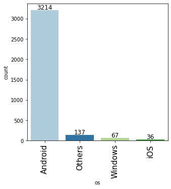

```python
# os
labeled_barplot(df1, 'os')
```

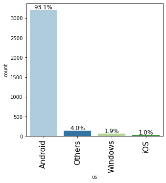

```python
# os (in percent)
labeled_barplot(df1, 'os', perc = True)
```

### Observations

- 93.1% of devices run on Android.
- After Android, the most common device os's are Others, Windows, and iOS.
- iOS only accounts for 1% of the device os's, which is very close to the percentage of devices that are Apple (~1.1%)

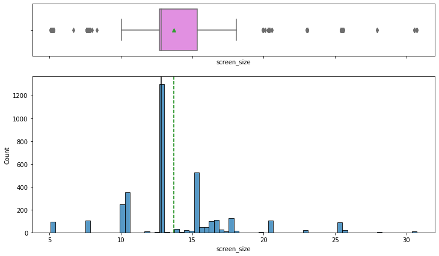

```python
# screen_size
histogram_boxplot(df1, 'screen_size')
```

### Observations

- There are outliers on both sides of the boxplot with what appears to be more outliers past the right tail than the left tail.
- The mean is greater than the median, and visually the screen_size distribution has a sizeable right skew.
- This right skew might be due to the tablets in this dataset, which will have much larger screen sizes than smartphones.

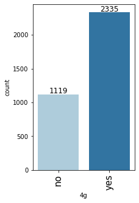

```python
# 4g
labeled_barplot(df1, '4g')
```

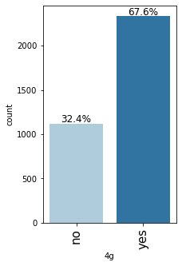

```python
# 4g (in percent)
labeled_barplot(df1, '4g', perc = True)
```

### Observations

- 67.6% of devices have 4G.
- The rest of the devices don't have 4G meaning they could have 5G, 2G, 3G, or no cellular connectivity.
- Since most devices have 4G, that could increase the asking used price for a device since it is common.

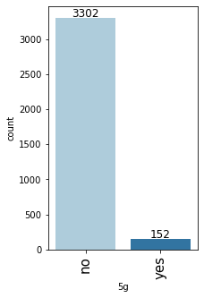

```python
# 5g
labeled_barplot(df1, '5g')
```

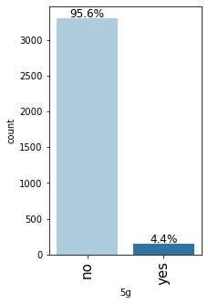

```python
# 5g (in percent)
labeled_barplot(df1, '5g', perc = True)
```

### Observations

- 95.6% of devices don't have 5G, which means they could be 4G, 2G, 3G, or have no cellular connectivity.
- The 3302 of devices not having 5G matches the number of devices that have 4G or something else (2335 + 1119 - 152 = 3302)
- The rest of the devices have 5G, which means that could potentially increase the selling price for the devices since it is a rarity, and 5G networks start to expand as the next generation of cellular networks.

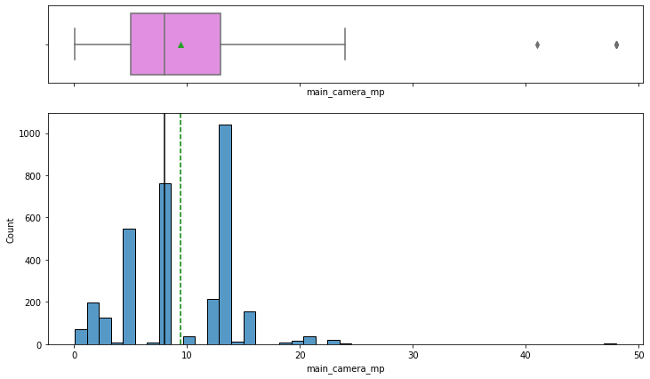

```python
# main_camera_mp
histogram_boxplot(df1, 'main_camera_mp')
```

### Observations

- There are outliers on the right side of the boxplot with what appears to be outliers much greater than 1.5 * InterQuartile Range.
- The mean is greater than the median, and visually the main_camera_mp distribution is highly skewed to the right.
- main_camera_mp does have 179 missing values (approx 5.2% values missing). When addressed along with outliers, the distribution skew might change.

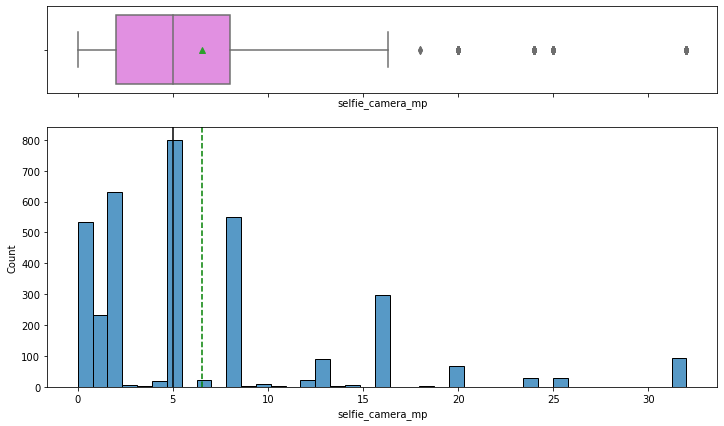

```python
# selife_camera_mp
histogram_boxplot(df1, 'selfie_camera_mp')
```

### Observations

- There are outliers on the right side of the boxplot.
- The mean is greater than the median, and visually the selfie_camera_mp distribution is highly skewed to the right.
- selfie_camera_mp has 2 missing values. When addressed along with outliers, there might not be much (if any) change to the distribution/distribution skew.

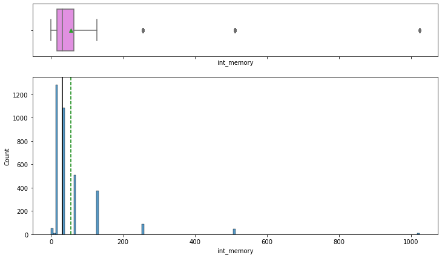

```python
# int_memory
histogram_boxplot(df1, 'int_memory')
```

### Observations

- There are outliers on the right side of the boxplot with what appears to be outliers much greater than 1.5 * InterQuartile Range.
- The mean is greater than the median, and visually the int_memory distribution is highly skewed to the right.
- int_memory does have 4 missing values. When addressed along with outliers, there might not be much (if any) change to the distribution/distribution skew.

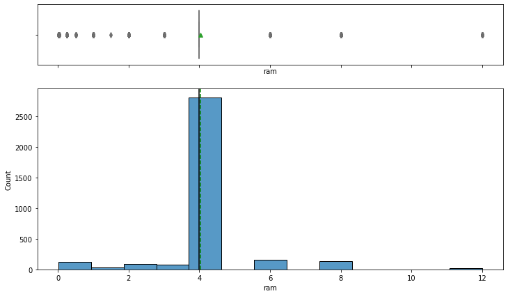

```python
# ram
histogram_boxplot(df1, 'ram')
```

### Observations

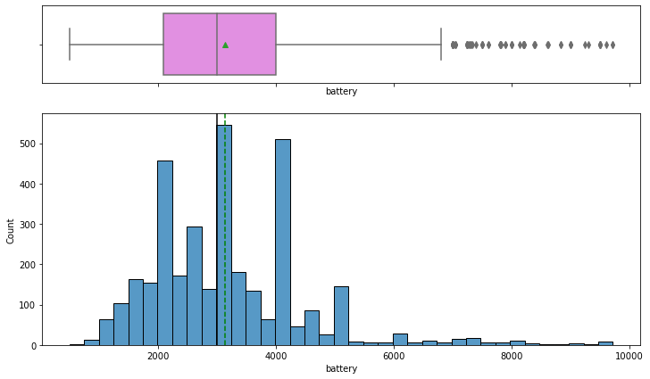

```python
# battery
histogram_boxplot(df1, 'battery')
```

### Observations

- There are outliers on the right side of the boxplot.
- The mean is greater than the median, and visually the battery distribution is highly skewed to the right.
- battery does have 6 missing values. When addressed along with outliers, there might not be (if any) much change to the distribution/distribution skew.

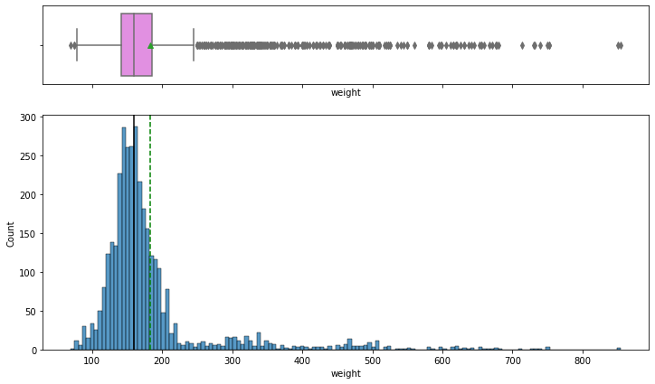

```python
# weight
histogram_boxplot(df1, 'weight')
```

### Observations

- There are outliers on the right side of the boxplot with what appears to be outliers much greater than 1.5 * InterQuartile Range.
- The mean is greater than the median, and visually the weight distribution is highly skewed to the right.
- weight does have 7 missing values. When addressed along with outliers, there might not be much (if any) change to the distribution/distribution skew.

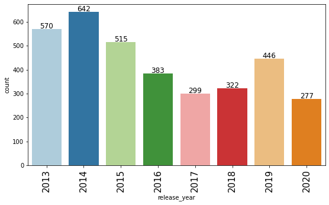

```python
# release_year
labeled_barplot(df1, 'release_year')
```

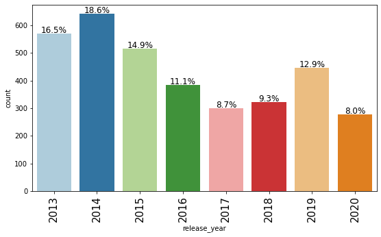

```python
# release_year (in percent)
labeled_barplot(df1, 'release_year', perc = True)
```

### Observations

- The most used devices being sold are from 2014 (18.6%) followed by 2013 (16.5%) and 2015 (14.9%).
- The year with the fourth most devices are from 2019 (12.9%), which might go for a higher price since they are more recent.

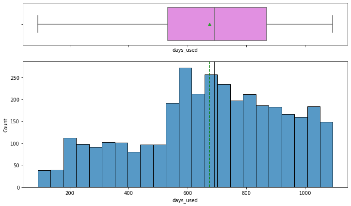

```python
# days_used
histogram_boxplot(df1, 'days_used')
```

### Observations

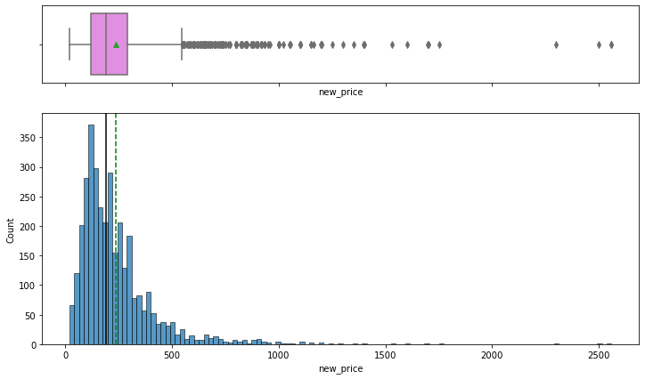

```python
# new_price
histogram_boxplot(df1, 'new_price')
```

### Observations

- There are outliers on the right side of the boxplot with what appears to be outliers much greater than 1.5 * InterQuartile Range.
- The mean is greater than the median, and visually the new_price distribution is highly skewed to the right.
- The devices that are outliers might be considered premium devices that very few people buy, which means they might lead to a higher asking price for a used version of the device.

```python
# used_price
histogram_boxplot(df1, 'used_price')
```

[output not shown]

### Observations

- There are outliers on the right side of the boxplot with what appears to be outliers much greater than 1.5 * InterQuartile Range.
- The mean is greater than the median, and visually the used_price distribution is highly skewed to the right.
- The devices that are outliers might be considered premium devices that are being resold that people couldn't afford buying new and might opt to buy used.
- The price scale for new_price is 0-2500 Euros vs. 0-700+ Euros for used_price. The used price for an expensive device is about ~70% lower than new.

## Bivariate Analysis

```python
# Finding correlations of all attributes with used_price sorted in descending order
df1[df1.columns[:]].corr()['used_price'][:].sort_values(ascending = False)
```

```
used_price          1.000000
new_price           0.809335
selfie_camera_mp    0.614675
battery             0.549647
ram                 0.529434
screen_size         0.529275
release_year        0.494910
main_camera_mp      0.459209
int_memory          0.378347
weight              0.357983
days_used          -0.385777
Name: used_price, dtype: float64
```

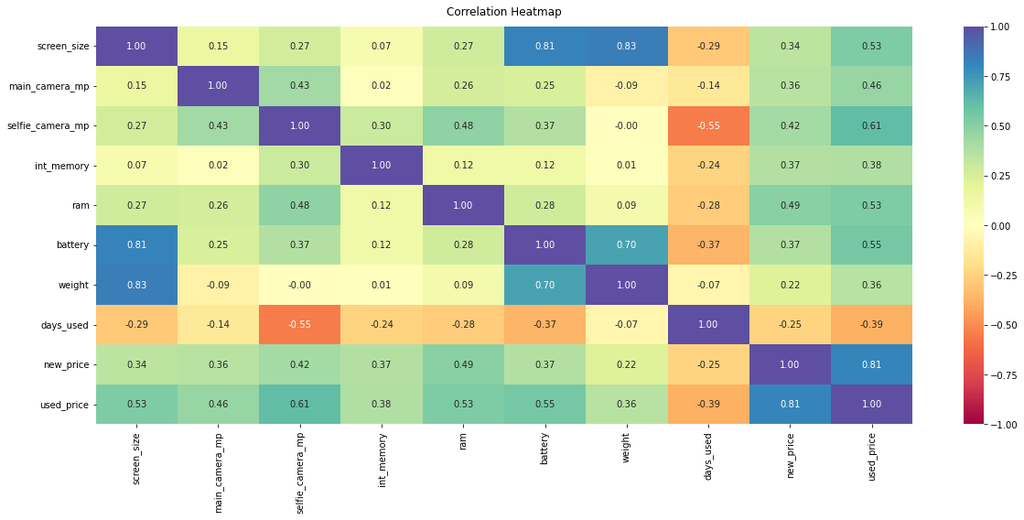

```python
# Specifying numeric columns for a correlation heatmap
numeric_columns = df1.select_dtypes(include = np.number).columns.tolist()

# Dropping release_year since it is a temporal variable
numeric_columns.remove('release_year')

# Correlation heatmap
plt.figure(figsize=(20, 8))

# Store heatmap object in a variable to easily access it when you want to include more features (such as title).
# Set the range of values to be displayed on the colormap from -1 to 1, and set the annotation to True to display the correlation values on the heatmap.
heatmap = sns.heatmap(df1[numeric_columns].corr(), annot = True, vmin = -1, vmax = 1, fmt = '.2f', cmap = 'Spectral')

# Give a title to the heatmap. Pad defines the distance of the title from the top of the heatmap.
heatmap.set_title('Correlation Heatmap', fontdict={'fontsize':12}, pad=12);
```

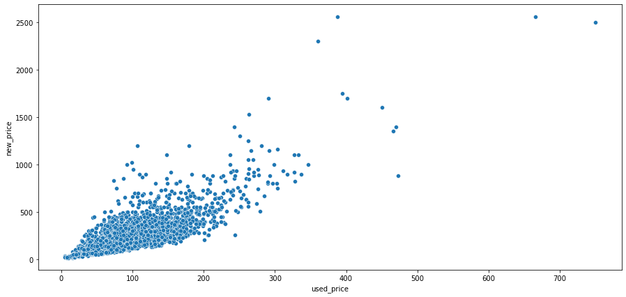

```python
# used_price vs new_price
plt.figure(figsize=(15,7))
sns.scatterplot(x = 'used_price', y = 'new_price', data = df1)
plt.show()
```

### Observations

- The correlation between used_price and new_price is ~0.81.
- The correlation between used_price and new_price is very strong until about 300-350 Euro for used_price, and then there appears to be multiple outliers.

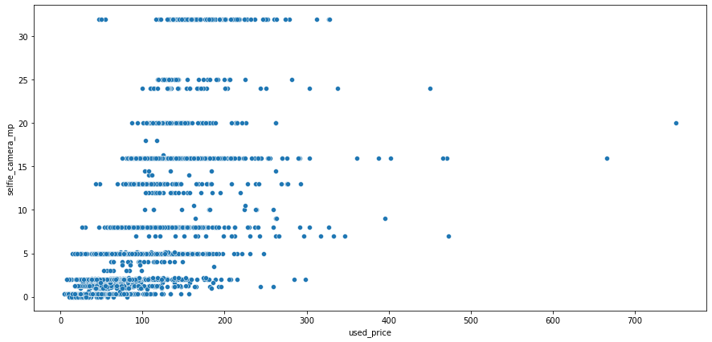

```python
# used_price vs selfie_camera_mp
plt.figure(figsize=(15,7))
sns.scatterplot(x = 'used_price', y = 'selfie_camera_mp', data = df1)
plt.show()
```

### Observations

- The correlation between used_price and selfie_camera_mp is 0.61.
- The correlation between used_price and selfie_camera_mp seems to have most of the data between 0-250 Euro used_price and then there appears to be multiple outliers.

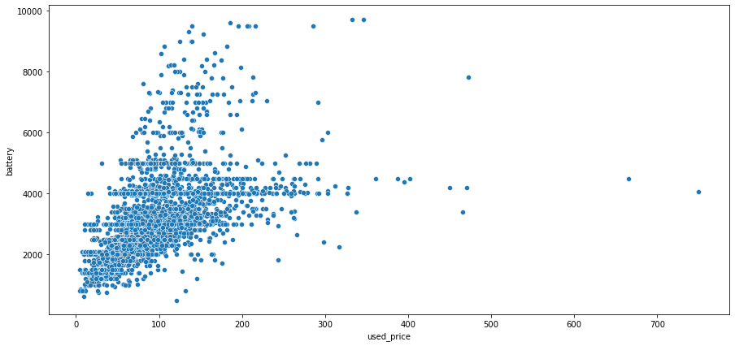

```python
# used_price vs battery
plt.figure(figsize=(15,7))
sns.scatterplot(x = 'used_price', y = 'battery', data = df1)
plt.show()
```

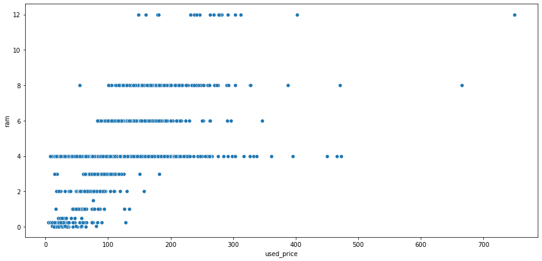

```python
# used_price vs ram
plt.figure(figsize=(15,7))
sns.scatterplot(x = 'used_price', y = 'ram', data = df1)
plt.show()
```

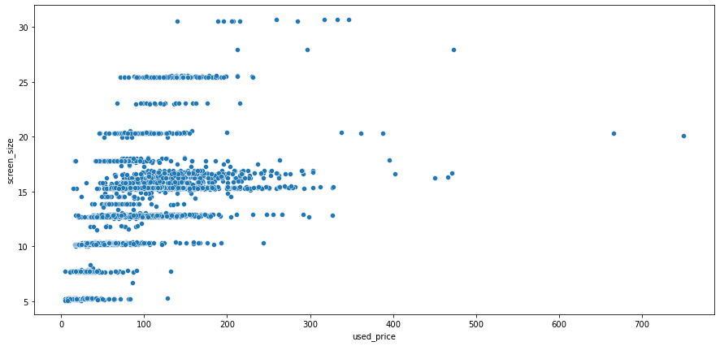

```python
# used_price vs screen_size
plt.figure(figsize=(15,7))
sns.scatterplot(x = 'used_price', y = 'screen_size', data = df1)
plt.show()
```

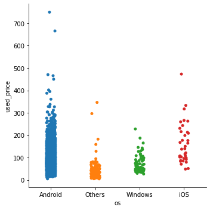

```python
# used_price vs os catplot
sns.catplot(x = 'os', y = 'used_price' , data = df1)
plt.show()
```

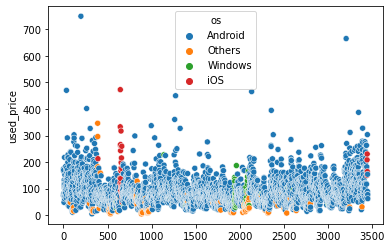

```python
# used_price vs os scatter plot
sns.scatterplot(x = df1.index, y = 'used_price', hue = 'os', data = df1)
plt.show()
```

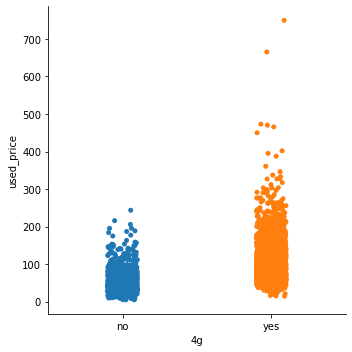

```python
# used_price vs 4G catplot
sns.catplot(x = '4g', y = 'used_price' , data = df1)
plt.show()
```

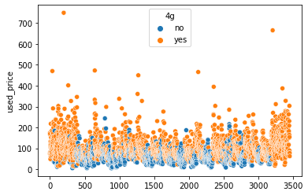

```python
# used_price vs 4g scatterplot
sns.scatterplot(x = df1.index, y = 'used_price', hue = '4g', data = df1)
plt.show()
```

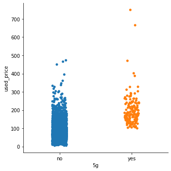

```python
# used_price vs 5G catplot
sns.catplot(x = '5g', y = 'used_price' , data = df1)
plt.show()
```

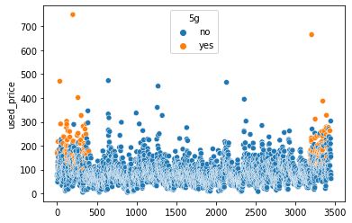

```python
# used_price vs 5g scatter plot
sns.scatterplot(x = df1.index, y = 'used_price', hue = '5g', data = df1)
plt.show()
```

```python
# used_price vs brand_name
# used_price average per brand_name
df1.groupby('brand_name')['used_price'].mean().sort_values(ascending = False)
```

```
brand_name
OnePlus       183.223636
Apple         172.015385
Google        138.597333
Oppo          130.043566
Vivo          126.787094
Xiaomi        122.796288
Huawei        122.436813
Honor         114.489138
Meizu         108.286935
Realme        107.493171
Sony          101.721977
Samsung       101.570059
Asus           98.752295
Motorola       91.343962
HTC            88.801273
Gionee         88.591786
Lenovo         87.475380
ZTE            86.898286
Coolpad        84.915455
LG             84.610149
Infinix        81.126000
BlackBerry     80.341364
Microsoft      75.838636
Others         75.383606
Acer           73.611176
Panasonic      71.296809
Nokia          61.760943
Alcatel        60.090496
XOLO           53.538571
Lava           51.867500
Micromax       50.304957
Karbonn        49.286552
Spice          44.024333
Celkon         32.210909
Name: used_price, dtype: float64
```

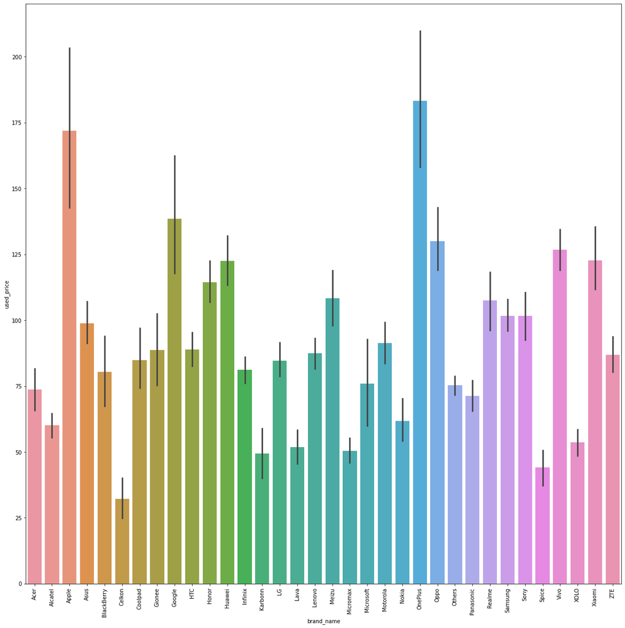

```python
# used_price vs. brand_name barplot
plt.figure(figsize = (20,20))
sns.barplot(data = df1, x = 'brand_name', y = 'used_price')
plt.xticks(rotation = 90)
plt.show()
```

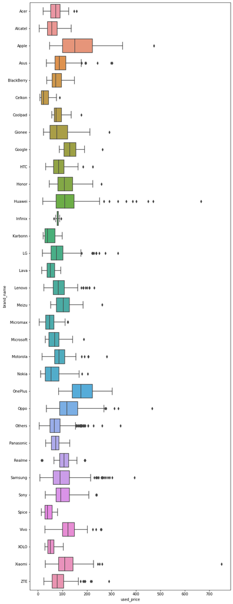

```python
# used_price vs. brand_name boxplot
plt.figure(figsize = (10,30))
sns.boxplot(data = df1, y = 'brand_name', x = 'used_price')
plt.show()
```